# Brown Algae and Invertebrates at San Nicolas Island

Owen Liu

August 16, 2016

## An Empirical Dynamic Exploration

### 1. Introduction

This project will use data from a long-term monitoring project at San Nicolas Island to investigate dynamic interactions and predictability between kelp forest brown algae species (*Macrocystis pyrifera* and understory kelps), and various species of invertebrates. We will see how well these species can predict each other’s dynamics, and resolve competitive and predatory/herbivorous interactions in real time across the timeframe of the dataset. The species we will look at are:

- Brown algaes:
- *Macrocystis pyrifera*, giant kelp
- *Laminaria* species (combined)
- *Cystoseira osmundacea*
- *Pterogophora californica*
- *Eisenia arborea*, southern sea palm
- Echinoderms
- *Strongylocentrotus purpuratus*, purple sea urchin
- *S. franciscanus*, red sea urchin
- *Patiria miniata*, bat star
- *Pisaster giganteus*, giant sea star
- *Parastichopus parvimensis*, warty sea cucumber
- Gastropods
- *Megastraea undosa*, wavy turban snail

### 2. Getting a Sense of the Data

Our first task is just to look at the data over time. Let’s explore (normalized) time series of our different variables.

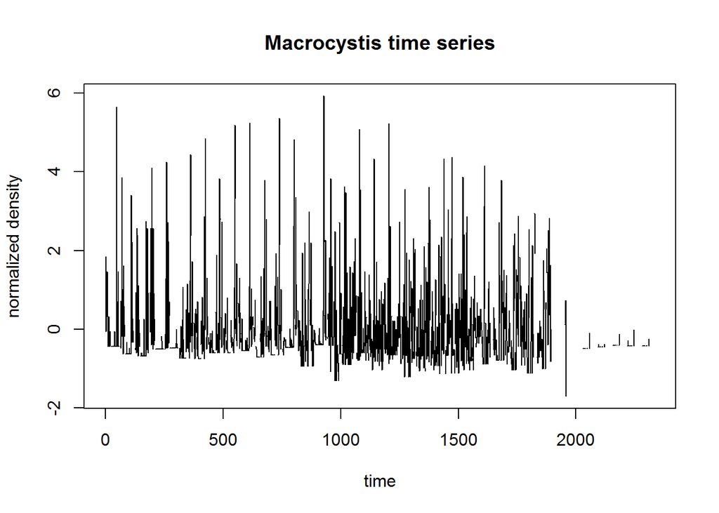

```r
plot(dat.norm.block$mac,type="l",main="Macrocystis time series",xlab="time",ylab="normalized density")
```

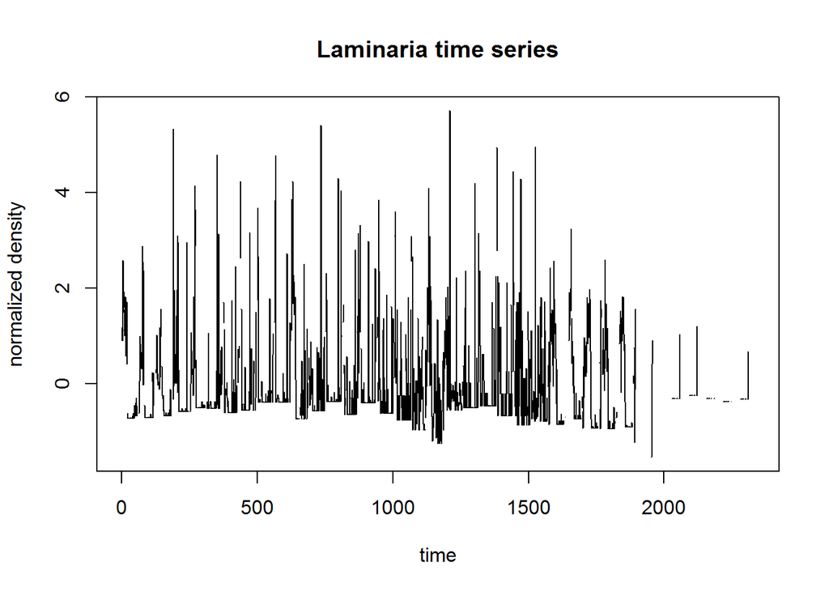

```r
plot(dat.norm.block$lam,type="l",main="Laminaria time series",xlab="time",ylab="normalized density")
```

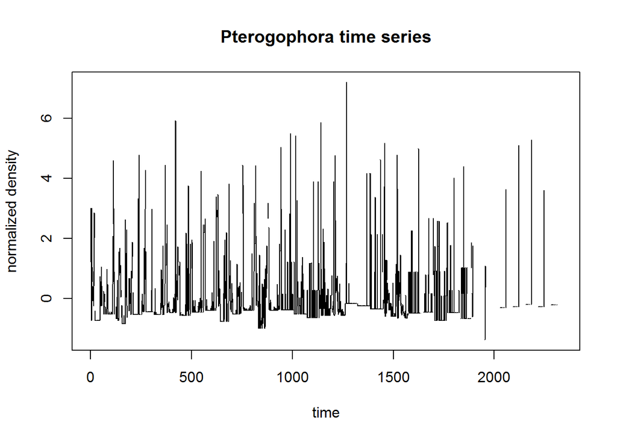

```r
plot(dat.norm.block$pter,type="l",main="Pterogophora time series",xlab="time",ylab="normalized density")
```

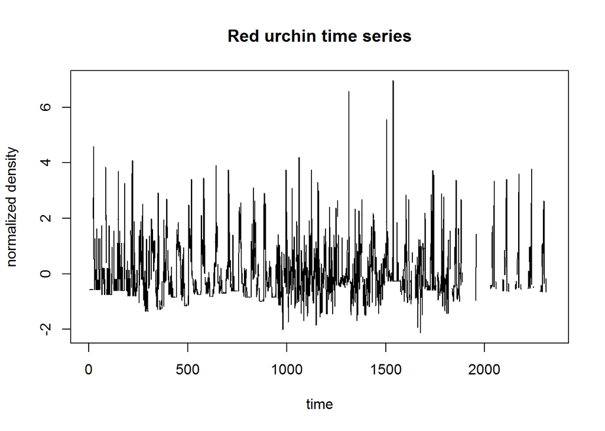

```r
plot(dat.norm.block$red,type="l",main="Red urchin time series",xlab="time",ylab="normalized density")
```

```r
# For many of these time series, the last few 'sites', from SNI station 7, in the combined time series look like they have different dynamics. Let's remove them from the data.  We do more quantitative tests of the validity of combining sites' data below.

dat.norm.block <- dat.norm.block %>% filter(!grepl("7",site))
```

### 3. Establishing univariate predictability and nonlinearity

For each of these time series, we have a few steps to see if they seem appropriate to analyze together. First, for each species/variable separately, we’ll search for signals of deterministic behavior, or self-predictability, using simplex projection (which will also give us an idea of the appropriate embedding dimension). Then, we look for nonlinear dynamics with S-maps. Finally, we can determine cross-predictability across sites to make sure it is appropriate to use all the data together.

First, let’s use simplex projection to investigate each species’ self predictability.

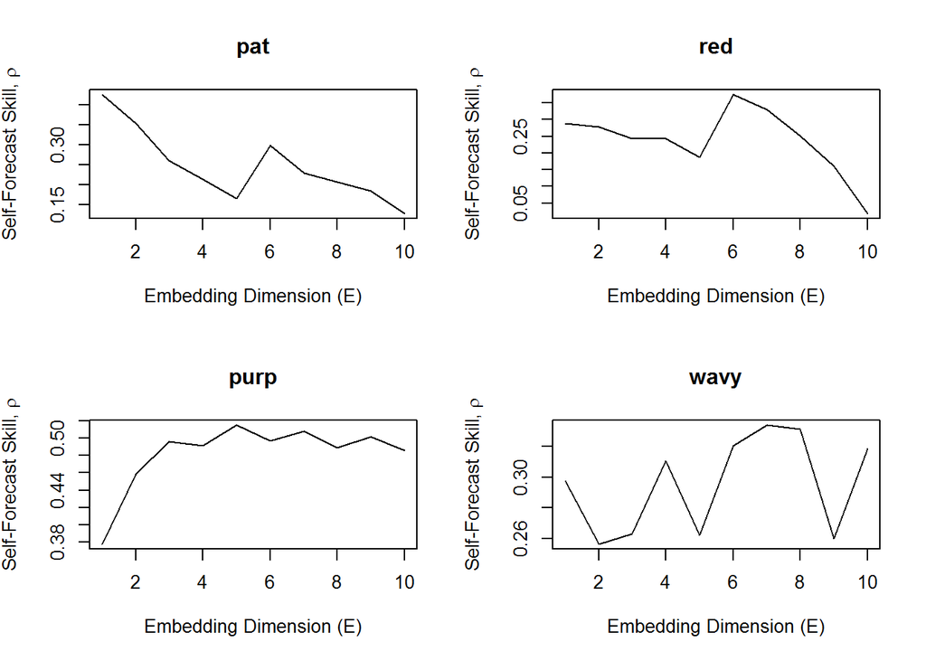

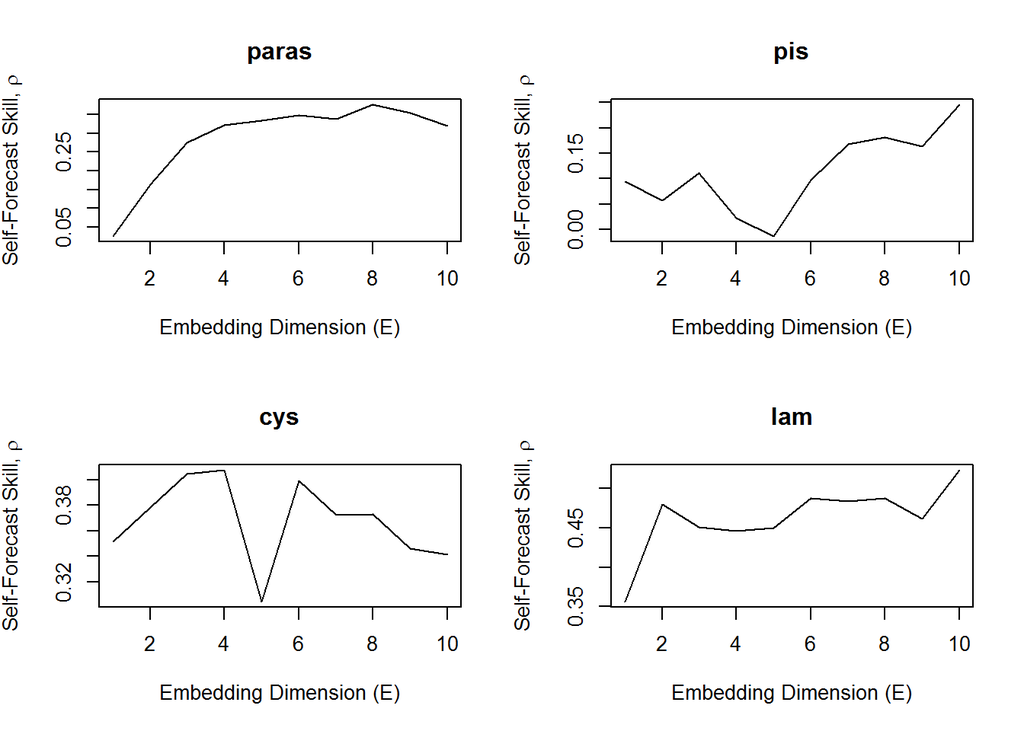

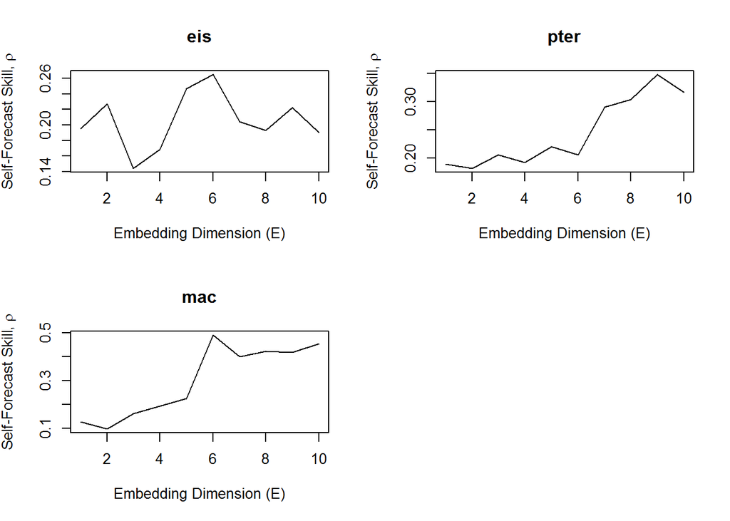

```r
# For all the steps in the univariate analyses, we need an indication of the breaks in the different sites, or concurrent time series
# This piece of code holds the row numbers of the first and last element of each time series
segs_sites <- dat.norm.block %>%
  mutate(ind = row_number()) %>%
  group_by(site) %>%
  summarise(first=first(ind),last=last(ind))

segs <- select(segs_sites,-site)

# For this step, we use all the concatenated data
simp.list <- list() # list to store output

par(mfrow=c(2,2))
for(i in 1:length(study_spp)) {
  spp <- study_spp[i]
  dat <- dat.norm.block %>% select(matches(spp)) %>% as.data.frame()
  out <- simplex(as.numeric(dat[,1]),lib=as.matrix(segs),silent=T)
  simp.list[[spp]] <- out

  # Plot embedding dimension vs. predictive ability (rho)
  plot(out$E,out$rho,type="l",main=spp,xlab="Embedding Dimension (E)",ylab=expression(paste("Self-Forecast Skill, ",rho)))

}
```

We can also look at prediction decay, another important property of deterministic chaos. This makes sure that nearby trajectories eventually diverge over time (the “butterfly effect”). Helps in distinguishing nonlinear systems from equilibrium-type systems. We want prediction to decline over time. For this simplex projection, we hold E, the embedding dimension, constant, and vary the prediction horizon, tp

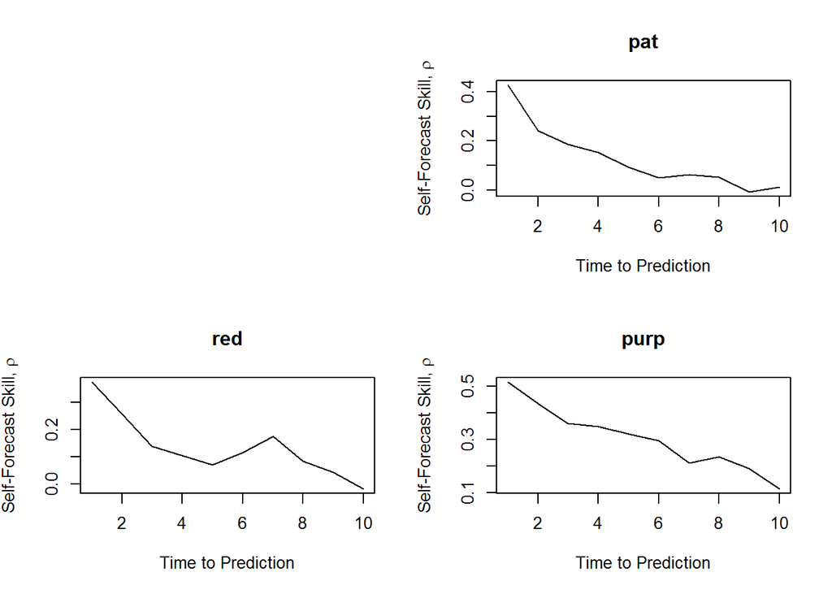

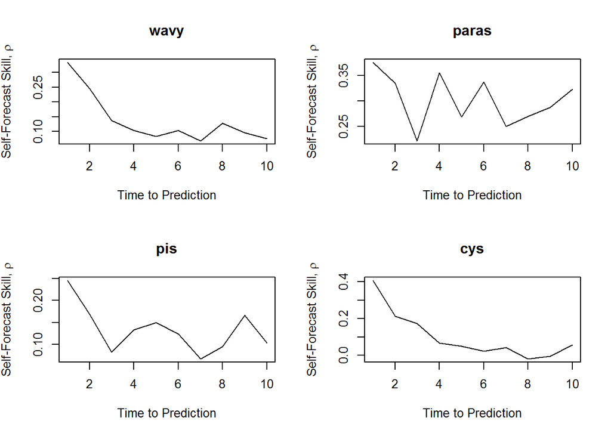

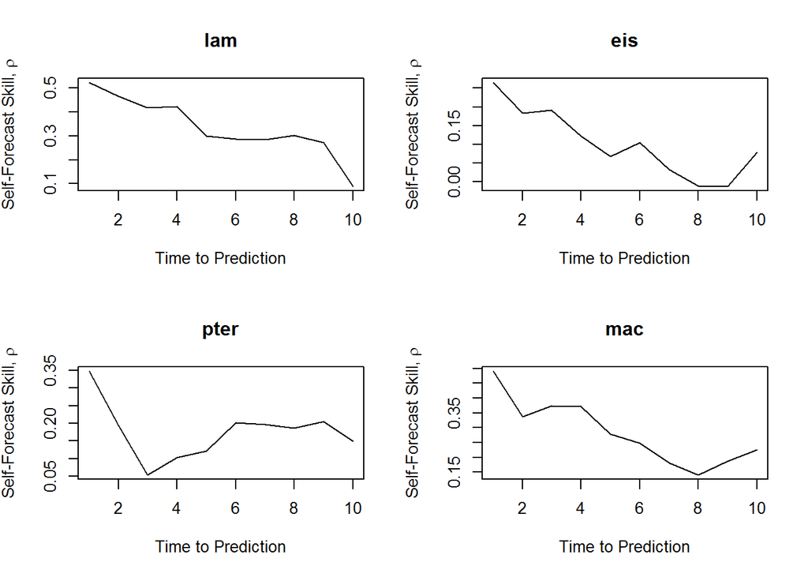

```r
# Find best embedding dimension from previous step
bestE <- sapply(simp.list,function(x) x$E[x$rho==max(x$rho)])
tp.list <- list()

par(mfrow=c(2,2))
plot.new()
for(i in 1:length(study_spp)) {
  spp <- study_spp[i]
  dat <- dat.norm.block %>% select(matches(spp)) %>% as.data.frame()
  out <- simplex(as.numeric(dat[,1]),lib=as.matrix(segs),silent=T,E=bestE[i],tp=1:10)
  tp.list[[spp]] <- out

  # Plot embedding dimension vs. predictive ability (rho)
  plot(out$tp,out$rho,type="l",main=spp,xlab="Time to Prediction",ylab=expression(paste("Self-Forecast Skill, ",rho)))
}
```

Next is to look for nonlinearity with S-maps. The S-maps procedure has a parameter, $\theta$, that can “tune” the projection algorithm to weight local state-space neighborhoods more highly, the implication being that if predictability improves with increased $\theta$, variables are better predicted by local neighborhoods rather than global linear models, indicating state-dependence or nonlinearity of dynamics.

For prediction of each variable, we’ll use the optimal embedding dimension found in the previous step (the E with highest predictive ability).

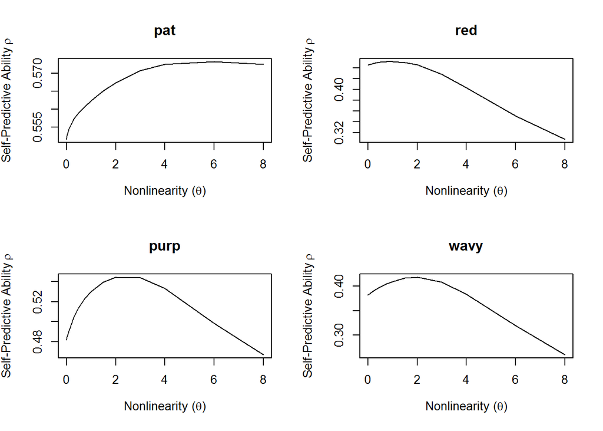

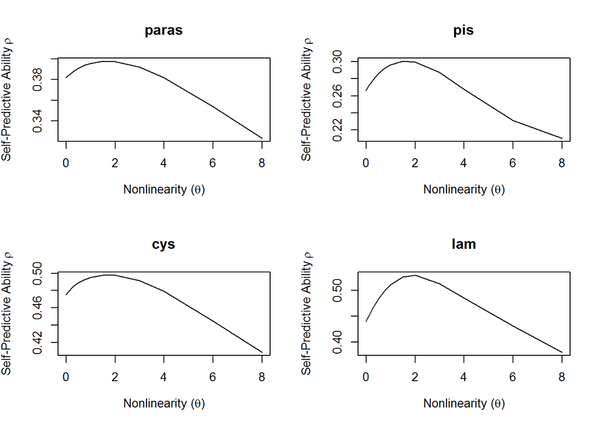

```r
smap.list <- list() # list to store output

par(mfrow=c(2,2))
for(i in 1:length(study_spp)) {
  spp <- study_spp[i]
  dat <- dat.norm.block %>% select(matches(spp)) %>% as.data.frame()
  out <- s_map(as.numeric(dat[,1]),lib=as.matrix(segs),E=bestE[i],silent=T)
  smap.list[[spp]] <- out

  # Plot embedding dimension vs. predictive ability (rho)
  plot(out$theta,out$rho,type="l",main=spp,xlab=expression(paste("Nonlinearity (",theta,")")),ylab=expression(paste("Self-Predictive Ability ",rho)))
}
```

```r
ptm<-proc.time()
test<-simplex(as.numeric(dat[,1]),lib=as.matrix(segs)[1:5,],pred=as.matrix(segs)[11:15,],silent=T)
proc.time()-ptm
```

```
##    user  system elapsed
##    0.07    0.00    0.08
```

[figure not shown]

Now we have to check to see if different sites have cross-predictability, to validate our choice to pool all of the data. To do this is a bit tricky. The data collected at San Nicolas Island is nested: transects within sites. Here, we’ll keep the individual transect time series within each site pooled, but test for predictability *between sites*.

For each species, we’ll use simplex projection, but varying the “library” and “prediction” sets to explicit match the 6 different sites and see how well they can cross-predict. Because this is not necessarily a symmetrical process (e.g., for a given species, site 1 may predict the dynamics of site 2 better than site 2 can predict site 1), there will be 36 runs for each species (6 sites times 6 crosses per site, itself and the 5 other sites). To make the output cleaner, we’ll simply extract the best rho from each run, and ensure that it is significantly greater than zero.

```r
# For each individual simplex run, we use a subset of the block data, according to the original segments key:
site_rows <- segs_sites %>%
  separate(site,into=c("site","transect"),sep="_") %>%
  select(-transect) %>%
  as.data.frame()

# This is a list, each element holding an identifier of the subset time series (the transects) within each site.
site_rows_list <- split(site_rows,site_rows$site)
# Possible combinations of sites
site.combinations <- expand.grid(1:6,1:6) %>%
  rename(libs=Var1,preds=Var2)

# List to hold output of cross-checks
dat.comb.check <- list()

# Run the simplex projections
for(i in 1:length(study_spp)) {
  spp <- study_spp[i]
  dat <- dat.norm.block %>% select(matches(spp)) %>% as.data.frame()
  dat <- as.numeric(dat[,1])
  out.mat <- matrix(nrow=6,ncol=6,dimnames=list(as.character(1:6),as.character(1:6)))

  # For each species, test each combination of sites
  for(j in 1:nrow(site.combinations)) {
    # Form a set of library and prediction vectors from different sites
    lib <- site.combinations[j,1]
    pred <- site.combinations[j,2]

    # Run the simplex model, pulling the correct library and prediction vectors from the list of site-specific time series
    simp <- simplex(dat,lib=as.matrix(site_rows_list[[lib]][,2:3]),pred=as.matrix(site_rows_list[[pred]][,2:3]),silent=T)

    # Pull out the best predictive ability between the two sites. If all p-values (using Fisher's z) greater than 0.05, return NA
    if(min(simp$p_val>0.05)) {
      out <- NA
    } else {
      out <- max(simp$rho)
    }
    out.mat[lib,pred] <- out
  }

  # For each species, return matrix of sites' cross-predictability
  dat.comb.check[[spp]] <- out.mat
}
```

We can plot 6 by 6 raster-type grids for each species, displaying the results of this exercise.

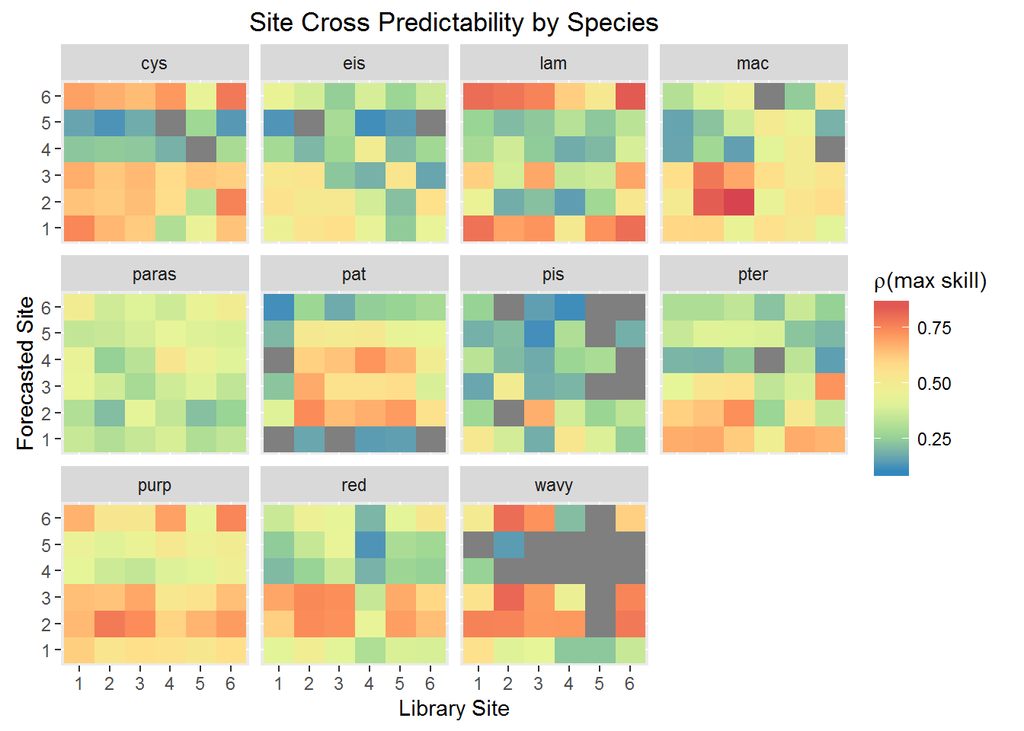

Rows or columns that appear gray (NA, non-significant forecast skill) or very cool (blue-ish) in these plots indicate sites for each species that may not be appropriate to include, as their dynamics are not significantly cross-predictable. A couple of things to notice:

The next step will be to see if these species show signs of causative links.

### 4. Determining Causation Between Species

Generalizations of Takens’ theorem indicate that if two variables (in our case, species) are part of the same dynamic system, their individual dynamics should reflect their relative causal influence. In other words, if one variable (for example, giant kelp), is casually forced by another (sea urchins), that forcing should leave a signature on the giant kelp time series. Convergent cross mapping (CCM) tests for causation by using the attractor/manifold built from the time series of one variable to forecast another. If the attractor can accurately (based on out-of-sample prediction skill, just as before) predict the dynamics of the second variable, we can claim that the second variable has a causal influence on the first. In other words, if A causes B, we should be able to recover the dynamics of A using a reconstruction of B. We say that the *causal effect of A on B is determined by how well B cross-maps A*.

Cross-mapping can distinguish unidirectional forcing (A forces B but B doesn’t force A) from bi-directional (A and B force each other). It can also resolve transitive causal chains (A causes B causes C). To look for a causal signal, we plot predictive skill against library size (the number of embedded vectors used to construct the attractor). There are two criteria for CCM to establish causality. First, and most obviously, predictive cross-map skill using all available data should be significantly greater than zero. Second, that predictability should be convergent. Convergence means that cross-mapped estimates improve with library length, because the attractor is more fully resolved and estimation error should decline.

We can use this theory to build a causal network in our kelp forest algae/invertebrate system.

CCM uses a random sampling method to test multiple “versions” of each library size, sampling from the supplied library vectors to give a sense of the confidence intervals around prediction skill. However, just like before, because we’re using multiple, simultaneous time series, we have to indicate the breaks in those time series so the algorithm does not try to make predictions spanning multiple time series. Also, to be more conservative, we’ll use only a random half of each time series for attractor reconstruction, and apply it to predicting the other half.

```r
# Block of time series for running CCM. Same as before, with the site identifier removed.
CCM.block <- dat.norm.block %>% select(-site) %>% as.data.frame()

set.seed(4215)
# Sample one half of time series segments, without replacement
rnd_lib_segs <- sample_frac(segs,0.5,replace=F) %>% arrange(first)
# Use other half for prediction
rnd_pred_segs <- anti_join(segs,rnd_lib_segs,by=c("first","last")) %>% arrange(first)

rnd_lib_segs <- as.matrix(rnd_lib_segs)
rnd_pred_segs <- as.matrix(rnd_pred_segs)
```

We can now apply CCM. Let’s start simple, and see which invertebrates seem to have a causal influence on *Macrocystis pyrifera*, the giant kelp, and vice versa. We accomplish this by building a library with *Macrocystis* vectors, and cross-mapping the invertebrates. For example, we can see if there is a causal signal between *Macrocystis* and the two urchin species:

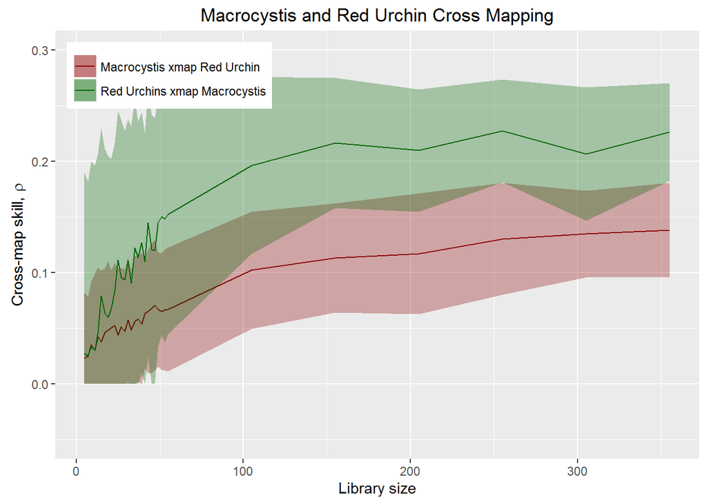

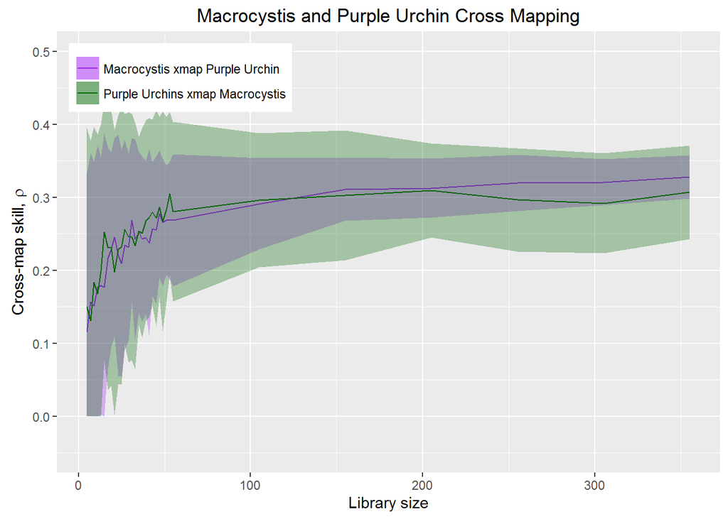

This initial look suggests that both urchin species affect, and are affected by, the giant kelp. In the red urchin case, the *Macrocystis* seems to drive red urchin dynamics more than urchins drive kelp, but in the case of purple urchins, there is evidence of bi-directional causation. For both cross-mappings, cross-map skill, while significantly greater than zero, is not particularly strong, suggesting there are other important variables to consider.

Applying CCM in this way to all combinations of species in our data, we can build a “causal web”, looking at the strength of cross-map skill between all species. Importantly, as evidenced by the red urchin example above, CCM is non-symmetrical, and hence the cross-map of A on B is not the same as the cross-map of B on A. For the sake of comparison, we can also build a traditional cross-correlation matrix between the same timeseries.

```r
ncol <- dim(CCM.block)[2]-1
col.names <- colnames(CCM.block)[2:(ncol+1)]
xmap_mat <- array(NA,dim=c(ncol,ncol),dimnames=list(col.names,col.names))

## CCM causation criterion 1: cross-map skill greater than zero
# matrix to store a bootstrapped p-value, measuring the probability that a given xmap is greater than zero (calculated as
# 1 minus the number of positive results for rho divided by the number of iterations)
p1.mat <- array(NA,dim=c(ncol,ncol),dimnames=list(col.names,col.names))

## CCM causation criterion 2: evidence for convergence
# similarly, matrix to store a bootstrapped p-value, this time a t-test value between library size 10 and library size 500, to see if the rho at large library is significantly greater than the rho at small library size (i.e., looking for convergence).  If rho does not converge with library length, it may be a sign of synchrony.
p2.mat <- array(NA,dim=c(ncol,ncol),dimnames=list(col.names,col.names))

# if both p1 and p2 are positive, indicate overall significant causal signal
ptot.mat <- array(NA,dim=c(ncol,ncol),dimnames=list(col.names,col.names))

## Run CCM for each combination of variables
for(i in 1:ncol) {
  for(j in 1:ncol) {
    if(i != j) {
      # remember, we use the best embedding dimension for the library variable (the predicted variable, j)
      tempE=bestE[col.names[j]]
      temp <- ccm(CCM.block,lib=rnd_lib_segs,pred=rnd_pred_segs,E=tempE,lib_column = 1+i,target_column = 1+j,
                  lib_sizes = c(10,500),replace=T,silent=T)
      # mean rho at library size 500
      rhomean <- temp %>% filter(lib_size==500) %>% ccm_means()
      xmap_mat[i,j] <- rhomean$rho

      # first p-value (greater than zero? at largest library size)
      p1 <- temp %>% filter(lib_size==500) %>% mutate(pos=ifelse(rho>0,1,0)) %>% summarise(p=(1-sum(pos)/n()))
      p1.mat[i,j] <- as.numeric(p1)

      # second p-value (rho at lib-size 500 greater than rho at lib-size 10?)
      p2 <- t.test(temp$rho[temp$lib_size==10],temp$rho[temp$lib_size==500])$p.value
      p2.mat[i,j] <- as.numeric(p2)

      # overall significance (both p1 and p2 signficant at alpha 0.05)
      ptot.mat[i,j] <- ifelse(p1<0.05 & p2<0.05,1,0)
    }
  }
}
```

We can output this result in a grid similar to before, except will all cross-species combinations instead of species x site

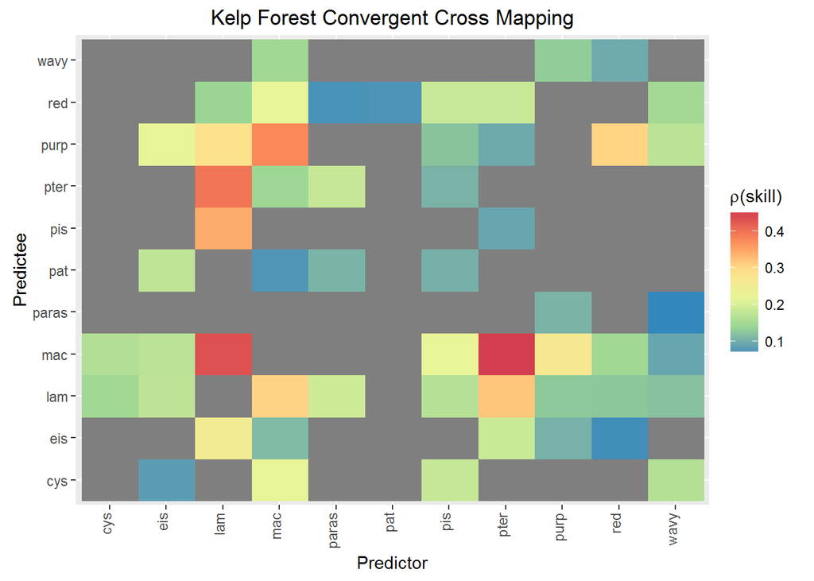

From this plot, we can draw a few conclusions. The predictors (causal variables) lie along the x-axis (columns), and the variables they cause are on the y-axis (rows). The strongest forcing variables of giant kelp dynamics are actually not the urchins, but rather two understory kelps, *Laminaria spp.* and *Pterogophora californica*. The *Macrocystis*, in turn, displays a causal effct on purple urchins *Strongylocentrotus purpuratus*, and to a lesser extent red urchins *S. franciscanus*, *Laminaria*, and *Cystoseira osmundacea*. Looking at the data another way, we can build an interaction web, and also see the number of link (causal or caused by) for each species (its network centrality).

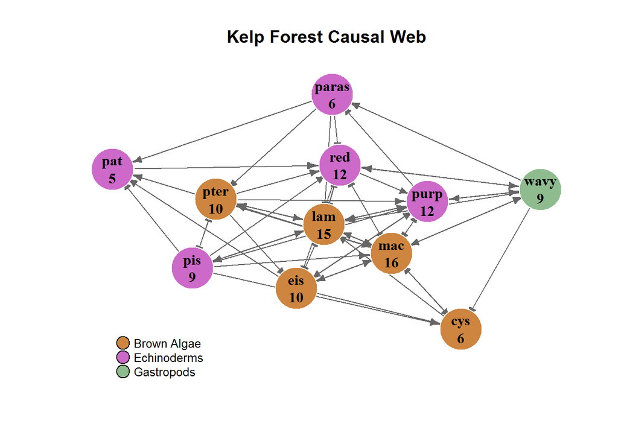

Although this is a busy network, it suggests two things to me, both of which agree with a lot of previous work:

- Kelp forests are dynamically complex, with an intricate network of causal interactions between species
- The algaes (primary producers) are central to dynamics, having the most connections, followed by the two urchin species

Given that these species are so interconnected, it may be that we could better predict dynamics by building composite attractors from multiple species’ time series. Similar to the theory behind CCM, extensions of Takens’ theorem provide the basis for multivariate state-space reconstruction. Using the normalized time series as before, we’ll build library vectors that include lagged coordinates of the variable we’re trying to predict, as well as other variables illuminated by our CCM analysis.

### 5. Multivariate CCM

We do not want to just throw all variables into our multivariate reconstructions. Instead, we can add variables one by one, to see how much predictability they add to the overall model. To keep it simple for now, we’ll focus on predicting the dynamics of *Macrocystis pyrifera*.

We start with a univariate reconstruction (lagged versions of the same time series, just as in Section 3)

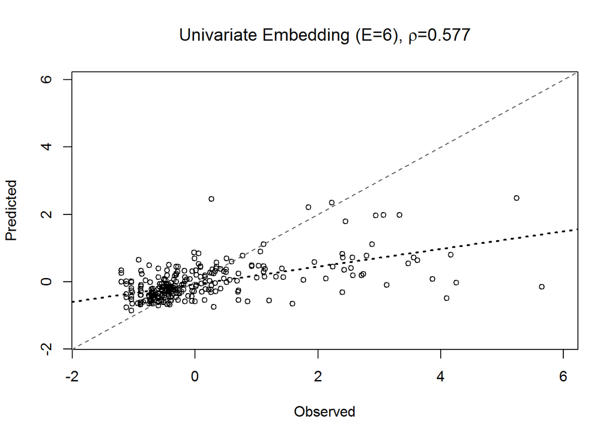

```r
# Create a block of time series
# Similar to the block used for CCM, but for multivariate embeddings we have to manually lag the variable
multiblock <- dat.norm.block %>%
  group_by(site) %>%
  # manual lags for macrocystis
  mutate(mac.lag1=lag(mac,1),mac.lag2=lag(mac,2),mac.lag3=lag(mac,3),mac.lag4=lag(mac,4),mac.lag5=lag(mac,5)) %>%
  # manual lags for pterogophora
  mutate(pter.lag1=lag(pter,1),pter.lag2=lag(pter,2)) %>%
  # manual lags for laminaria
  mutate(lam.lag1=lag(lam,1),lam.lag2=lag(lam,2)) %>%
  ungroup() %>%
  select(-site)

mac.univar <- block_lnlp(multiblock,lib=rnd_lib_segs,pred=rnd_pred_segs,columns=c("mac","mac.lag1","mac.lag2","mac.lag3","mac.lag4","mac.lag5"),target_column = "mac",stats_only = F,silent=T)

# We can plot observed vs. predicted values to see how well the univariate reconstruction did
univar.out <- mac.univar[[1]]$model_output

# Correlation between observed and predicted
univar.corr <- round(mac.univar[[1]]$stats$rho,3)

par(mfrow=c(1,1),xpd=F)
plot_range <- range(c(univar.out$obs, univar.out$pred), na.rm = TRUE)
plot(univar.out$obs,univar.out$pred,xlab="Observed",ylab="Predicted",xlim=plot_range,ylim=plot_range,cex=0.8,main=expression(paste("Univariate Embedding (E=6), ",rho,"=0.577")))

# "Perfect fit", 1:1 line
abline(a=0,b=1,lty=2,col="gray40")
# Best fit line
abline(lm(univar.out$pred ~ univar.out$obs), col = "black", lty = 3, lwd = 2)
```

Next, we’ll add the variable that had the best cross-map predictability of *Macrocystis* dynamics: *Pterogophora*.

The idea is the same, but we include the pterogophora time series as one more embedded dimension

```r
mac.multi.pter <- block_lnlp(multiblock,lib=rnd_lib_segs,pred=rnd_pred_segs,columns=c("mac","mac.lag1","mac.lag2","pter","pter.lag1","pter.lag2"),target_column = "mac",stats_only = F,silent=T)

mac.multi.pter[[1]]$stats$rho
```

```
## [1] 0.3439763
```